# Assignment 3

Jennifer Horowitz

9/22/2020

```r
baseball<-read_csv('baseballstats.csv')
baseball<-baseball %>%
  mutate(
    continent = case_when (
      birthCountry =="United States"~"North America",
      birthCountry =="Jamaica"~"North America",
      birthCountry =="Nicaragua"~"Central America",
      birthCountry =="Mexico"~"Central America",
      birthCountry =="Panama"~"Central America",
      birthCountry =="Cuba"~"Central America",
      birthCountry =="Curacao"~"South America",
      birthCountry =="Colombia"~"South America",
      TRUE ~ "other"
    )
  )
```

### Continuous Variables

#### Weight and Height

I start by comparing weight and height.

```r
corweightheight <- with(baseball,cor.test(weight,height))
corweightheight
```

```
##
##  Pearson's product-moment correlation
##
## data:  weight and height
## t = 22.754, df = 755, p-value < 2.2e-16
## alternative hypothesis: true correlation is not equal to 0
## 95 percent confidence interval:
##  0.5935277 0.6782415
## sample estimates:
##       cor
## 0.6378097
```

We can visualize the same relationship with a scatter plot. Weight and height are positively correlated. Pretty strong positive correlation between weight and height which is also statistically significant. Typically the taller people get the heavier they are.

I’ll also add a trendline to the scatterplot using geom_smooth().

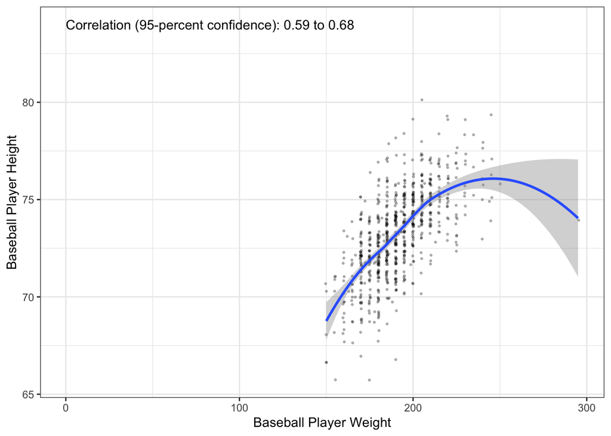

```r
ggplot(baseball, aes(x = weight, y = height)) +
  geom_point(size = 0.5, alpha = 0.25, position = "jitter") +
  geom_smooth() +
  theme_bw() +
  scale_x_continuous(name = "Baseball Player Weight") +
  scale_y_continuous(name = "Baseball Player Height") +
                     #breaks = seq(0, 6000, by = 500),
                    # labels = paste("$",
                                    #prettyNum(seq(0, 6000, by = 500),
                                              #big.mark = ","))) +
  annotate(geom = "text", x = 0, y = 84,
           label = paste("Correlation (95-percent confidence):",
                         prettyNum(corweightheight$conf.int[1], digits = 2),
                         "to",
                         prettyNum(corweightheight$conf.int[2], digits = 2)),
           hjust = 0)
```

#### Weight and Batting Average

```r
corweightandbatting <- with(baseball,cor.test(weight,batting_average))
corweightandbatting
```

```
##
##  Pearson's product-moment correlation
##
## data:  weight and batting_average
## t = 0.57562, df = 755, p-value = 0.565
## alternative hypothesis: true correlation is not equal to 0
## 95 percent confidence interval:
##  -0.05038771  0.09206351
## sample estimates:
##       cor
## 0.0209442
```

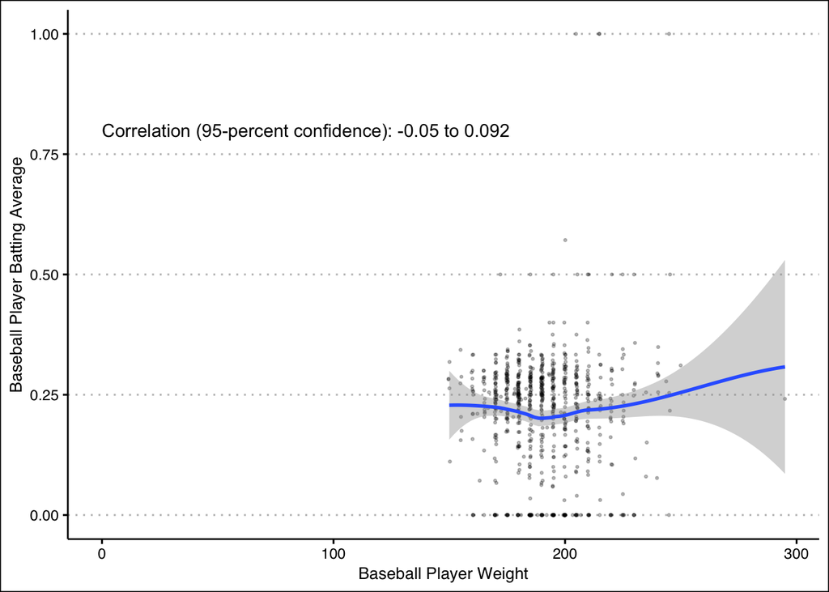

```r
ggplot(baseball, aes(x = weight, y = batting_average)) +
  geom_point(size = 0.5, alpha = 0.25, position = "jitter") +
  geom_smooth() +
  theme_clean() +
  scale_x_continuous(name = "Baseball Player Weight") +
  scale_y_continuous(name = "Baseball Player Batting Average") +
  annotate(geom = "text", x = 0, y = .8,
           label = paste("Correlation (95-percent confidence):",
                         prettyNum(corweightandbatting$conf.int[1], digits = 2),
                         "to",
                         prettyNum(corweightandbatting$conf.int[2], digits = 2)),
           hjust = 0)
```

Weight and batting average have almost no linear relationship. At the 95% confidence interval it exhibits no relationship– it’s not statistically signifcant. The p value = .5.

#### Weight and Slugging Average

```r
corweightandslugging <- with(baseball,cor.test(weight,slugging_average))
corweightandslugging
```

```
##
##  Pearson's product-moment correlation
##
## data:  weight and slugging_average
## t = 4.2651, df = 755, p-value = 2.252e-05
## alternative hypothesis: true correlation is not equal to 0
## 95 percent confidence interval:
##  0.08303646 0.22221356
## sample estimates:
##       cor
## 0.1533856
```

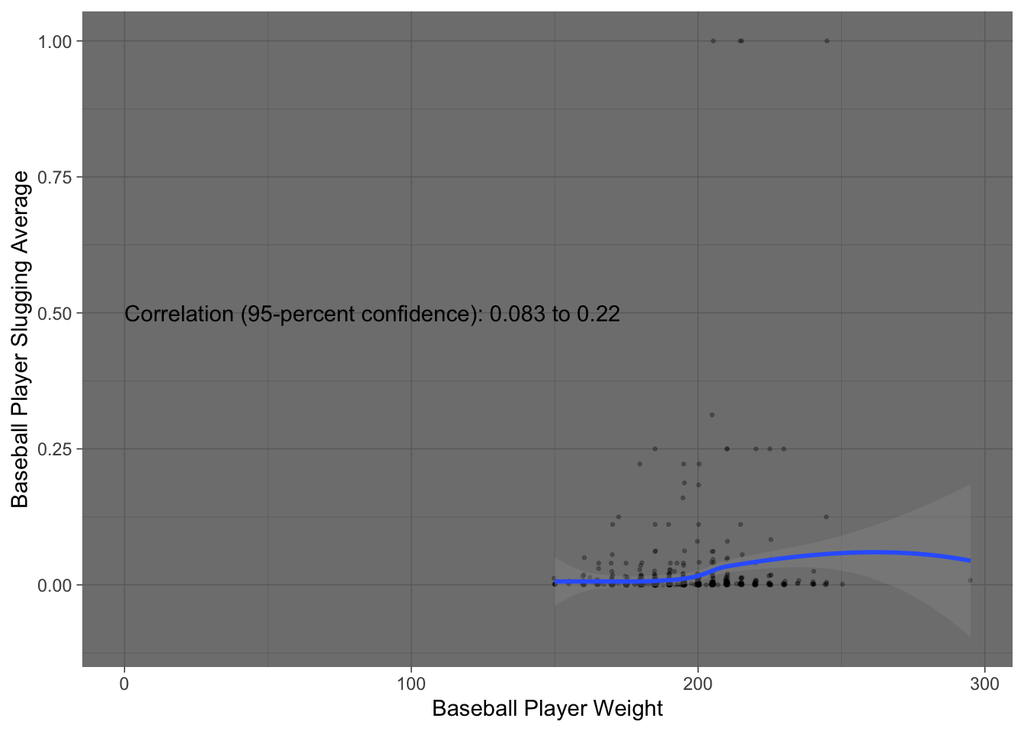

```r
ggplot(baseball, aes(x = weight, y = slugging_average)) +
  geom_point(size = 0.5, alpha = 0.25, position = "jitter") +
  geom_smooth() +
  theme_dark() +
  scale_x_continuous(name = "Baseball Player Weight") +
  scale_y_continuous(name = "Baseball Player Slugging Average") +
  annotate(geom = "text", x = 0, y = .5,
           label = paste("Correlation (95-percent confidence):",
                         prettyNum(corweightandslugging$conf.int[1], digits = 2),
                         "to",
                         prettyNum(corweightandslugging$conf.int[2], digits = 2)),
           hjust = 0)
```

#### Height and Slugging Average

```r
corheightandslugging <- with(baseball,cor.test(height,slugging_average))
corheightandslugging
```

```
##
##  Pearson's product-moment correlation
##
## data:  height and slugging_average
## t = 3.124, df = 755, p-value = 0.001852
## alternative hypothesis: true correlation is not equal to 0
## 95 percent confidence interval:
##  0.04204796 0.18275182
## sample estimates:
##       cor
## 0.1129662
```

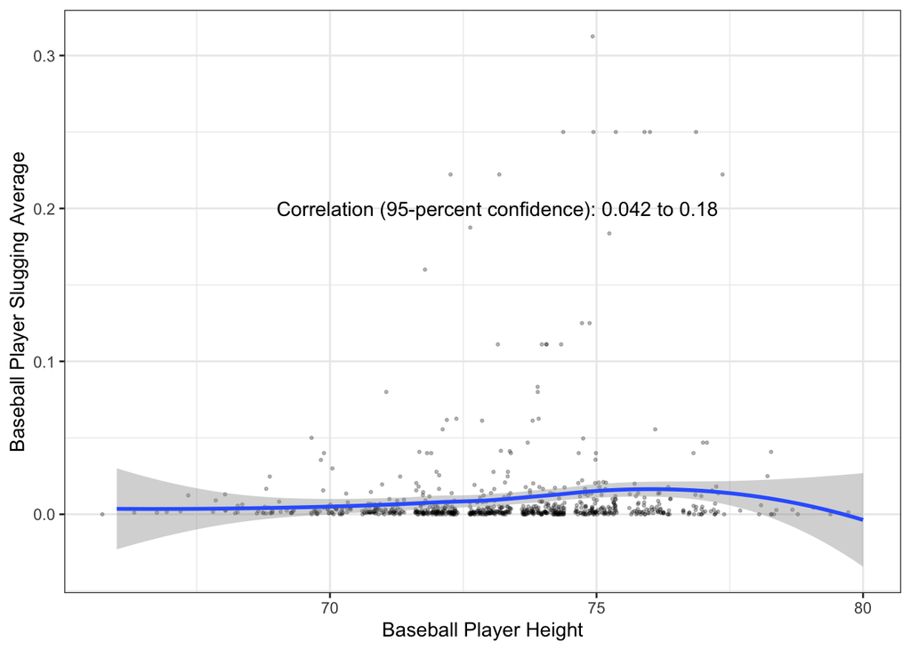

```r
baseball %>%
 filter(slugging_average<=0.4) %>%
  ggplot(aes(x = height, y = slugging_average)) +
  geom_point(size = 0.5, alpha = 0.25, position = "jitter") +
  geom_smooth() +
  theme_bw() +
  xlim(65,84) +
  scale_x_continuous(name = "Baseball Player Height") +
  scale_y_continuous(name = "Baseball Player Slugging Average") +
  annotate(geom = "text", x = 69, y = .2,
           label = paste("Correlation (95-percent confidence):",
                         prettyNum(corheightandslugging$conf.int[1], digits = 2),
                         "to",
                         prettyNum(corheightandslugging$conf.int[2], digits = 2)),
           hjust = 0)
```

#### Height and Batting Average

There is no linear relationship between these two variables. It is barely not statistically significant.

```r
corheightandbatting <- with(baseball,cor.test(height,batting_average))
corheightandbatting
```

```
##
##  Pearson's product-moment correlation
##
## data:  height and batting_average
## t = -1.9609, df = 755, p-value = 0.05026
## alternative hypothesis: true correlation is not equal to 0
## 95 percent confidence interval:
##  -1.417200e-01  7.500474e-05
## sample estimates:
##         cor
## -0.07118208
```

[figure not shown]

```r
ggplot(baseball, aes(x = height, y = slugging_average)) +
  geom_point(size = 0.5, alpha = 0.25, position = "jitter") +
  geom_smooth() +
  theme_bw() +
  xlim(65,84) +
  scale_x_continuous(name = "Baseball Player Height") +
  scale_y_continuous(name = "Baseball Player Slugging Average") +
  annotate(geom = "text", x = 70, y = .1,
           label = paste("Correlation (95-percent confidence):",
                         prettyNum(corheightandslugging$conf.int[1], digits = 2),
                         "to",
                         prettyNum(corheightandslugging$conf.int[2], digits = 2)),
           hjust = 0)
```

#### Slugging Average and Batting Average

```r
corsaandba<- with(baseball,cor.test(slugging_average,batting_average))
corsaandba
```

```
##
##  Pearson's product-moment correlation
##
## data:  slugging_average and batting_average
## t = 18.679, df = 755, p-value < 2.2e-16
## alternative hypothesis: true correlation is not equal to 0
## 95 percent confidence interval:
##  0.5114276 0.6090543
## sample estimates:
##       cor
## 0.5621964
```

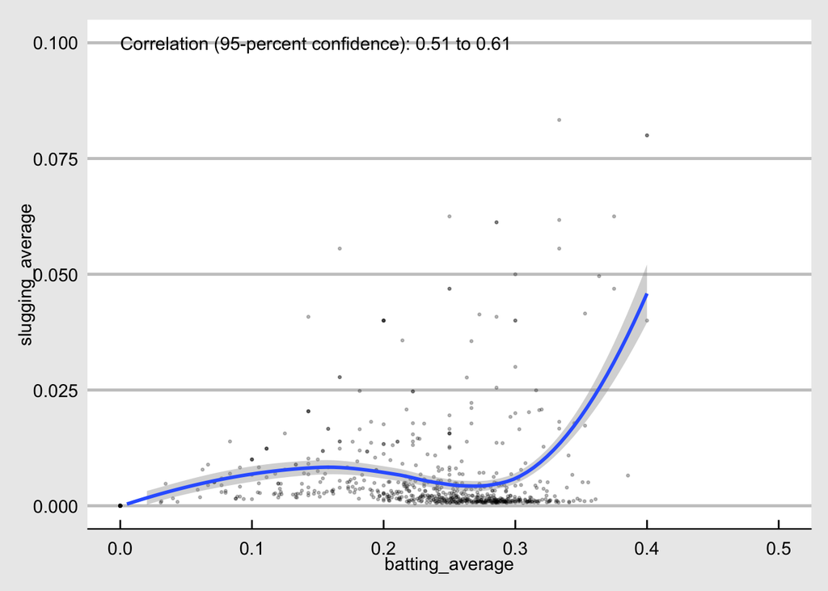

```r
ggplot(baseball, aes(x = batting_average, y = slugging_average)) +
  geom_point(size = 0.5, alpha = 0.25, position = "jitter") +
  geom_smooth() +
  theme_economist_white() +
  scale_x_continuous(name = "Batting Average") +
  scale_y_continuous(name = "Slugging Average") +
  xlim(0,0.5) +
  ylim(0,0.1) +
  annotate(geom = "text", x = 0, y = .1,
           label = paste("Correlation (95-percent confidence):",
                         prettyNum(corsaandba$conf.int[1], digits = 2),
                         "to",
                         prettyNum(corsaandba$conf.int[2], digits = 2)),
           hjust = 0)
```

### Continuous Variable vs. Categorical Variable (3+ levels)

#### Weight vs. Bats

There is a significant association between weight and bats.

```r
weightbatsanova <- aov(weight ~ bats, data = baseball)
summary(weightbatsanova)
```

```
##              Df Sum Sq Mean Sq F value   Pr(>F)
## bats          2   9016    4508   13.98 1.09e-06 ***
## Residuals   754 243060     322
## ---
## Signif. codes:  0 '***' 0.001 '**' 0.01 '*' 0.05 '.' 0.1 ' ' 1
```

```r
weightbatsdif <- TukeyHSD(weightbatsanova)
as_tibble(cbind(pair = row.names(weightbatsdif$bats),
               weightbatsdif$bats))
```

```
## # A tibble: 3 x 5
##   pair  diff             lwr                upr              `p adj`
##   <chr> <chr>            <chr>              <chr>            <chr>
## 1 L-B   7.70931034482757 2.2942949298016    13.1243257598535 0.00249965959074916
## 2 R-B   10.8835656639765 5.96257642472664   15.8045549032264 7.8850161244759e-07
## 3 R-L   3.17425531914893 -0.385390986077614 6.73390162437547 0.0917165681956431
```

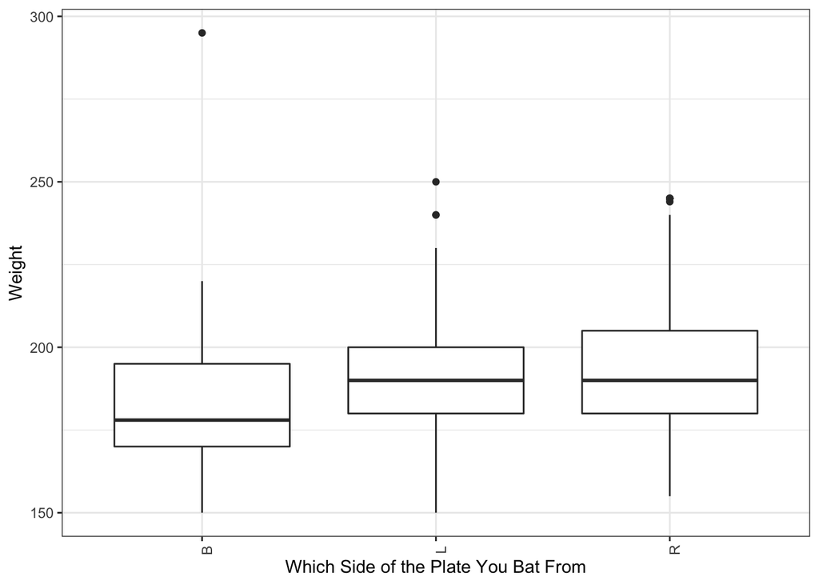

```r
ggplot(baseball, aes(x =bats, y = weight)) +
  geom_boxplot() +
  theme_bw() +
  theme(axis.text.x = element_text(angle = 90)) +
  scale_x_discrete(name = "Which Side of the Plate You Bat From") +
  scale_y_continuous(name = "Weight")
```

#### Weight vs. Continents

There is not a significant linear relationship between weight and continent.

```r
weightcontinentanova <- aov(weight ~ continent, data = baseball)
summary(weightcontinentanova)
```

```
##              Df Sum Sq Mean Sq F value Pr(>F)
## continent     3    455   151.6   0.454  0.715
## Residuals   753 251621   334.2
```

```r
weightcontinentdif <- TukeyHSD(weightcontinentanova)
as_tibble(cbind(pair = row.names(weightcontinentdif$continent),
               weightcontinentdif$continent))
```

```
## # A tibble: 6 x 5
##   pair                   diff           lwr           upr          `p adj`
##   <chr>                  <chr>          <chr>         <chr>        <chr>
## 1 North America-Central… -3.5638493723… -13.13993360… 6.012234861… 0.7731907232…
## 2 other-Central America  -4.0066666666… -20.53601842… 12.52268508… 0.9243401789…
## 3 South America-Central… 3.49333333333… -25.26501707… 32.25168374… 0.9893963838…
## 4 other-North America    -0.4428172942… -14.14308805… 13.25745347… 0.9997933143…
## 5 South America-North A… 7.05718270571… -20.17369439… 34.28805980… 0.9093870968…
## 6 South America-other    7.49999999999… -22.88155275… 37.88155275… 0.9205036878…
```

The heaviest players originated from Central and South America.

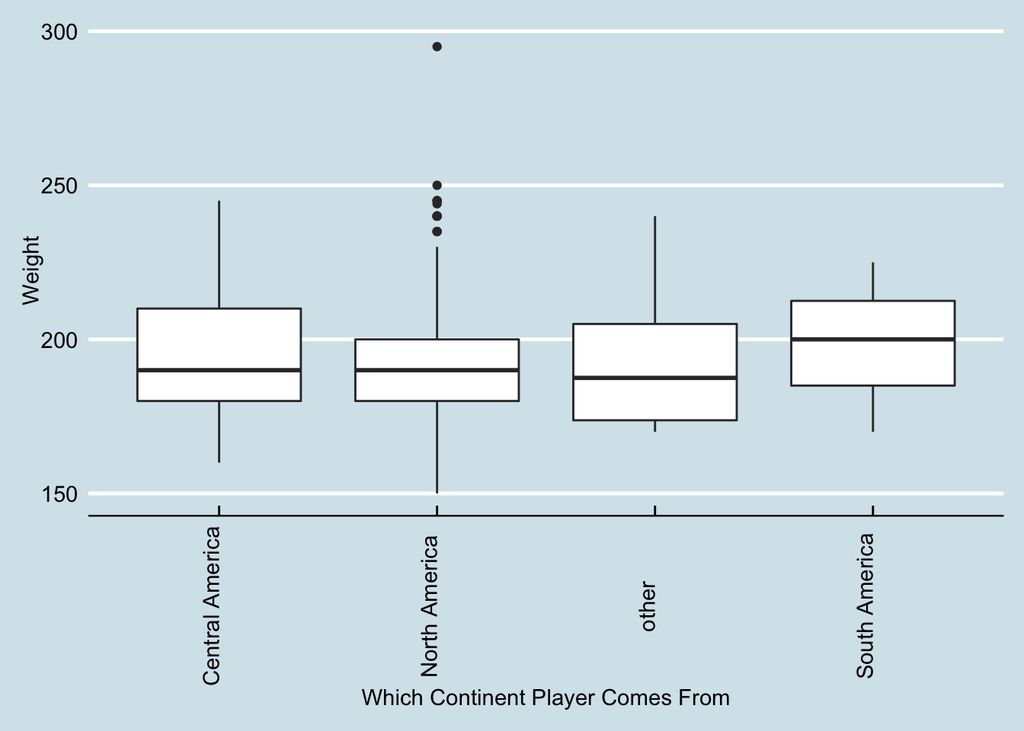

```r
ggplot(baseball, aes(x = continent, y = weight)) +
  geom_boxplot() +
  theme_economist() +
  theme(axis.text.x = element_text(angle = 90)) +
  scale_x_discrete(name = "Which Continent Player Comes From") +
  scale_y_continuous(name = "Weight")
```

#### Height and Bats

There is a significant association between height and bats.

```r
heightbatsanova <- aov(height ~ bats, data = baseball)
summary(heightbatsanova)
```

```
##              Df Sum Sq Mean Sq F value   Pr(>F)
## bats          2    155   77.33   16.21 1.28e-07 ***
## Residuals   754   3598    4.77
## ---
## Signif. codes:  0 '***' 0.001 '**' 0.01 '*' 0.05 '.' 0.1 ' ' 1
```

```r
heightbatsdif <- TukeyHSD(heightbatsanova)
as_tibble(cbind(pair = row.names(heightbatsdif$bats),
               heightbatsdif$bats))
```

```
## # A tibble: 3 x 5
##   pair  diff              lwr               upr              `p adj`
##   <chr> <chr>             <chr>             <chr>            <chr>
## 1 L-B   1.16701149425288  0.508193004701609 1.82582998380414 0.0001051491091144…
## 2 R-B   1.44935191978477  0.850639183214461 2.04806465635509 5.02790069578651e-…
## 3 R-L   0.282340425531899 -0.1507443623042… 0.7154252133680… 0.276976806456777
```

The people that bat from both sides are on the shorter end of the height data available.

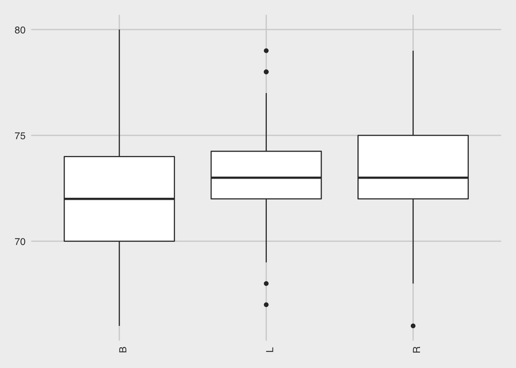

```r
ggplot(baseball, aes(x =bats, y = height)) +
  geom_boxplot() +
  theme_fivethirtyeight() +
  theme(axis.text.x = element_text(angle = 90)) +
  scale_x_discrete(name = "Which Side of the Plate You Bat From") +
  scale_y_continuous(name = "Height")
```

#### Height and Continent

There is not a significant relationship between the two variables.

```r
heightcontinentanova <- aov(height ~ continent, data = baseball)
summary(heightcontinentanova)
```

```
##              Df Sum Sq Mean Sq F value Pr(>F)
## continent     3     30   9.904   2.003  0.112
## Residuals   753   3723   4.944
```

```r
heightcontinentdif <- TukeyHSD(heightcontinentanova)
as_tibble(cbind(pair = row.names(heightcontinentdif$continent),
               heightcontinentdif$continent))
```

```
## # A tibble: 6 x 5
##   pair                  diff           lwr           upr          `p adj`
##   <chr>                 <chr>          <chr>         <chr>        <chr>
## 1 North America-Centra… 0.72128312412… -0.443516397… 1.886082645… 0.38240910819…
## 2 other-Central America 1.81333333333… -0.197235970… 3.823902637… 0.09390813273…
## 3 South America-Centra… -0.1866666666… -3.684726205… 3.311392871… 0.99907404346…
## 4 other-North America   1.09205020920… -0.574400131… 2.758500549… 0.33108210203…
## 5 South America-North … -0.9079497907… -4.220213117… 2.404313536… 0.89480859416…
## 6 South America-other   -1.9999999999… -5.695499877… 1.695499877… 0.50381328522…
```

There was no significant relationship between the two variables.

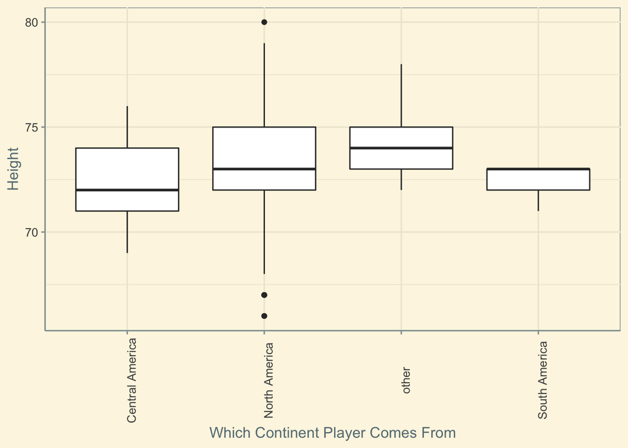

```r
ggplot(baseball, aes(x = continent, y = height)) +
  geom_boxplot() +
  theme_solarized() +
  theme(axis.text.x = element_text(angle = 90)) +
  scale_x_discrete(name = "Which Continent Player Comes From") +
  scale_y_continuous(name = "Height")
```

#### Batting Average and Bats

There is a significant association between batting average and which side of the plate players hit from.

```r
babatsanova <- aov(batting_average ~ bats, data = baseball)
summary(babatsanova)
```

```
##              Df Sum Sq Mean Sq F value   Pr(>F)
## bats          2  0.211 0.10528   6.985 0.000987 ***
## Residuals   754 11.365 0.01507
## ---
## Signif. codes:  0 '***' 0.001 '**' 0.01 '*' 0.05 '.' 0.1 ' ' 1
```

```r
babatsdif <- TukeyHSD(babatsanova)
as_tibble(cbind(pair = row.names(babatsdif$bats),
               babatsdif$bats))
```

```
## # A tibble: 3 x 5
##   pair  diff               lwr               upr               `p adj`
##   <chr> <chr>              <chr>             <chr>             <chr>
## 1 L-B   -0.02798635896725… -0.0650134598645… 0.00904074193003… 0.178720099760692
## 2 R-B   -0.04975442049670… -0.0834034410646… -0.0161053999287… 0.00157957480623…
## 3 R-L   -0.02176806152944… -0.0461084138277… 0.00257229076882… 0.09046671218714…
```

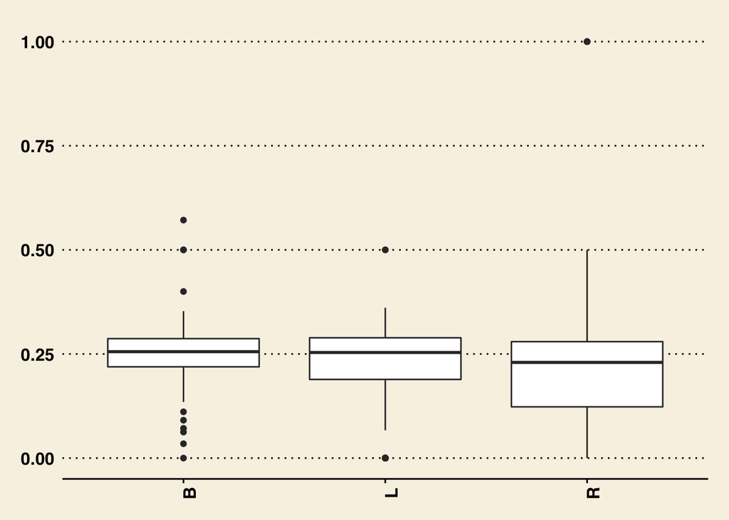

```r
ggplot(baseball, aes(x = bats, y = batting_average)) +
  geom_boxplot() +
  theme_wsj() +
  theme(axis.text.x = element_text(angle = 90)) +
  scale_x_discrete(name = "Side of the Plate Players Bat On") +
  scale_y_continuous(name = "Batting Average")
```

#### Batting Average and Continent

There is not a significant linear relationship between batting average and continent.

```r
bacontinentanova <- aov(batting_average ~ continent, data = baseball)
summary(bacontinentanova)
```

```
##              Df Sum Sq  Mean Sq F value Pr(>F)
## continent     3  0.018 0.006025   0.393  0.758
## Residuals   753 11.557 0.015348
```

```r
bacontinentdif <- TukeyHSD(bacontinentanova)
as_tibble(cbind(pair = row.names(bacontinentdif$continent),
             bacontinentdif$continent))
```

```
## # A tibble: 6 x 5
##   pair                 diff            lwr           upr           `p adj`
##   <chr>                <chr>           <chr>         <chr>         <chr>
## 1 North America-Centr… -0.02636344430… -0.091262515… 0.0385356273… 0.7224241416…
## 2 other-Central Ameri… -0.03311683385… -0.145139614… 0.0789059467… 0.8718555129…
## 3 South America-Centr… -0.01147512611… -0.206376319… 0.1834260670… 0.9987582587…
## 4 other-North America  -0.00675338955… -0.099602912… 0.0860961334… 0.9976694618…
## 5 South America-North… 0.014888318188… -0.169660877… 0.1994375139… 0.9968295981…
## 6 South America-other  0.021641707743… -0.184260258… 0.2275436735… 0.9930671771…
```

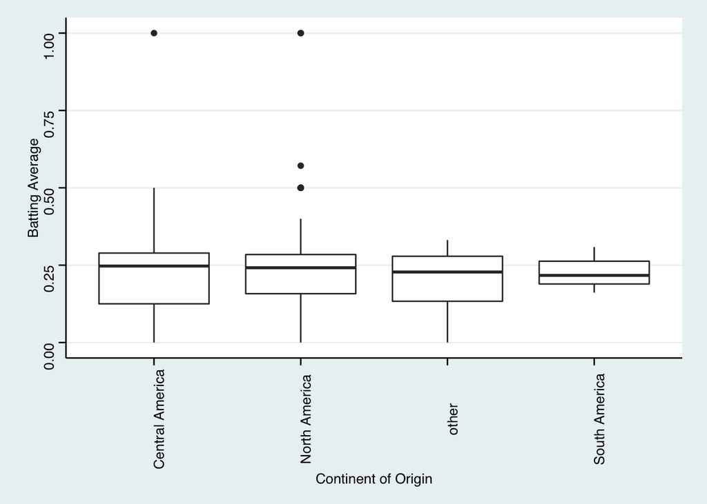

```r
ggplot(baseball, aes(x = continent, y = batting_average)) +
  geom_boxplot() +
  theme_stata() +
  theme(axis.text.x = element_text(angle = 90)) +
  scale_x_discrete(name = "Continent of Origin") +
  scale_y_continuous(name = "Batting Average")
```

#### Continent and Slugging Average

There is not a significant linear relationship between slugging average and continent.

```r
sacontinentanova <- aov(slugging_average ~ continent, data = baseball)
summary(sacontinentanova)
```

```
##              Df Sum Sq  Mean Sq F value Pr(>F)
## continent     3  0.038 0.012603   2.024  0.109
## Residuals   753  4.689 0.006227
```

```r
sacontinentdif <- TukeyHSD(sacontinentanova)
as_tibble(cbind(pair = row.names(sacontinentdif$continent),
             sacontinentdif$continent))
```

```
## # A tibble: 6 x 5
##   pair                 diff            lwr           upr           `p adj`
##   <chr>                <chr>           <chr>         <chr>         <chr>
## 1 North America-Centr… -0.03905626826… -0.080393370… 0.0022808343… 0.0719029081…
## 2 other-Central Ameri… -0.04390553391… -0.115257820… 0.0274467529… 0.3881677075…
## 3 South America-Centr… -0.05089672980… -0.175037960… 0.0732445008… 0.7166137600…
## 4 other-North America  -0.00484926565… -0.063989252… 0.0542907214… 0.9966729006…
## 5 South America-North… -0.01184046153… -0.129388044… 0.1057071218… 0.9938842049…
## 6 South America-other  -0.00699119588… -0.138139307… 0.1241569156… 0.9990769046…
```

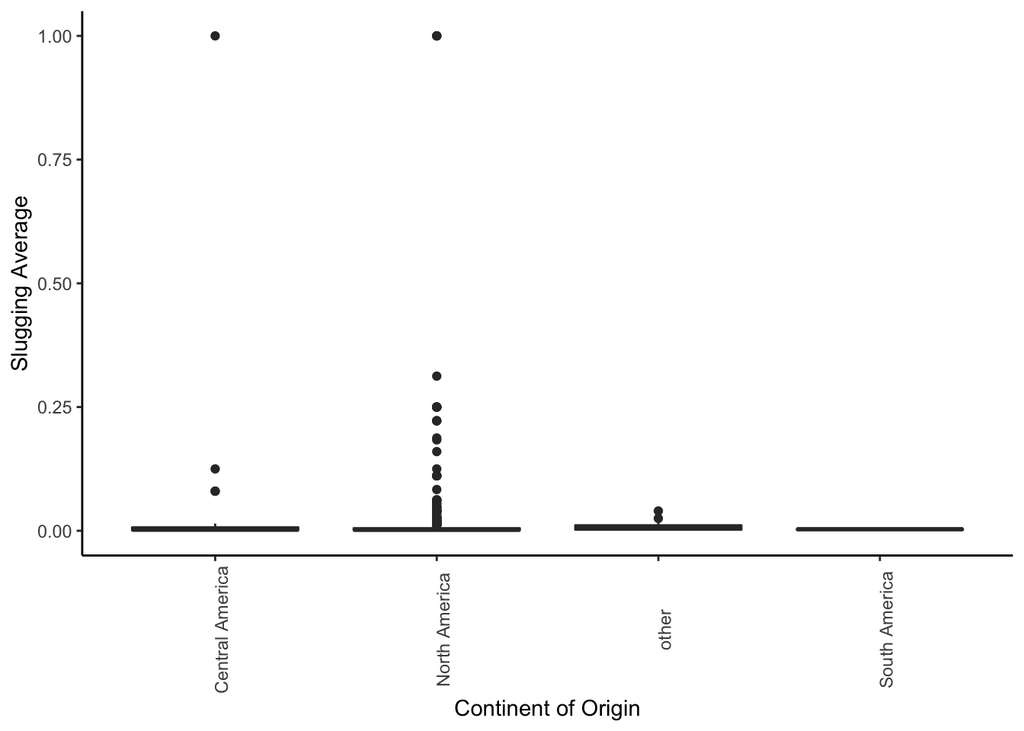

```r
ggplot(baseball, aes(x = continent, y = slugging_average)) +
  geom_boxplot() +
  theme_classic() +
  theme(axis.text.x = element_text(angle = 90)) +
  scale_x_discrete(name = "Continent of Origin") +
  scale_y_continuous(name = "Slugging Average")
```

### Chi Square Test: Two Categorical Variables

#### Bats and Continents

The linear relationship between bats and continents is not significant.

```r
chi_sq <- chisq.test(baseball$bats, baseball$continent)
chi_sq
```

```
##
##  Pearson's Chi-squared test
##
## data:  baseball$bats and baseball$continent
## X-squared = 8.5043, df = 6, p-value = 0.2034
```

```r
chi_sq$observed
```

```
##              baseball$continent
## baseball$bats Central America North America other South America
##             B               0            87     0             0
##             L               5           192     3             0
##             R              20           438     9             3
```

Here are the values we would expect if the two variables were not related:

```r
chi_sq$expected
```

```
##              baseball$continent
## baseball$bats Central America North America    other South America
##             B        2.873184      82.40291 1.379128     0.3447820
##             L        6.605020     189.43197 3.170410     0.7926024
##             R       15.521797     445.16513 7.450462     1.8626156
```